# 47_exp_shift_stretch_equiv

## 47_exp_shift_stretch_equiv

#### Question

1. For [exponential functions](https://en.wikipedia.org/wiki/Exponential_function), a horizontal shift is equivalent to a vertical stretch. Consider the two functions below, where $g$ is equivalent to $f$ stretched vertically by a factor $3$:

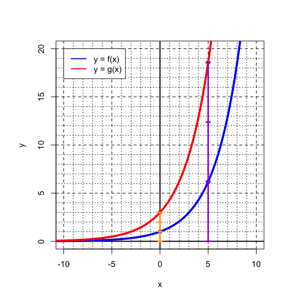

   $$\begin{align}
   f(x) &= 1.44^{x}\\\\
   g(x) &= 3\cdot 1.44^{x}
   \end{align}$$

   Instead of using the vertical stretch transformation, we could have used a horizontal shift. Notice the $g$ curve is congruent to the $f$ curve, just shifted to the left. Thus, we can express $g$ as a horizontally shifted version of $f$.

   $$g(x) = f(x+h)$$

   Or,

   $$g(x) = 1.44^{x+h}$$

   where $h$ represents the distance of the horizontal shift.
   - Find $h$. The tolerance is $\pm 0.01$.

#### Question

2. For [exponential functions](https://en.wikipedia.org/wiki/Exponential_function), a horizontal shift is equivalent to a vertical stretch. Consider the two functions below, where $g$ is equivalent to $f$ stretched vertically by a factor $3$:

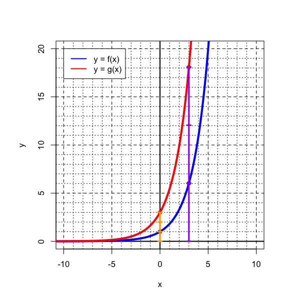

   $$\begin{align}
   f(x) &= 1.82^{x}\\\\
   g(x) &= 3\cdot 1.82^{x}
   \end{align}$$

   Instead of using the vertical stretch transformation, we could have used a horizontal shift. Notice the $g$ curve is congruent to the $f$ curve, just shifted to the left. Thus, we can express $g$ as a horizontally shifted version of $f$.

   $$g(x) = f(x+h)$$

   Or,

   $$g(x) = 1.82^{x+h}$$

   where $h$ represents the distance of the horizontal shift.
   - Find $h$. The tolerance is $\pm 0.01$.

#### Question

3. For [exponential functions](https://en.wikipedia.org/wiki/Exponential_function), a horizontal shift is equivalent to a vertical stretch. Consider the two functions below, where $g$ is equivalent to $f$ stretched vertically by a factor $3$:

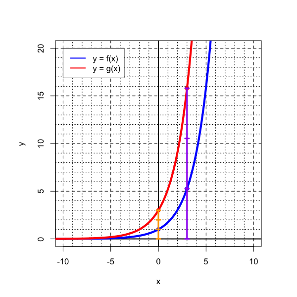

   $$\begin{align}
   f(x) &= 1.74^{x}\\\\
   g(x) &= 3\cdot 1.74^{x}
   \end{align}$$

   Instead of using the vertical stretch transformation, we could have used a horizontal shift. Notice the $g$ curve is congruent to the $f$ curve, just shifted to the left. Thus, we can express $g$ as a horizontally shifted version of $f$.

   $$g(x) = f(x+h)$$

   Or,

   $$g(x) = 1.74^{x+h}$$

   where $h$ represents the distance of the horizontal shift.
   - Find $h$. The tolerance is $\pm 0.01$.

#### Question

4. For [exponential functions](https://en.wikipedia.org/wiki/Exponential_function), a horizontal shift is equivalent to a vertical stretch. Consider the two functions below, where $g$ is equivalent to $f$ stretched vertically by a factor $3$:

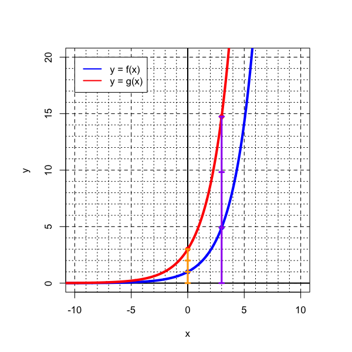

   $$\begin{align}
   f(x) &= 1.7^{x}\\\\
   g(x) &= 3\cdot 1.7^{x}
   \end{align}$$

   Instead of using the vertical stretch transformation, we could have used a horizontal shift. Notice the $g$ curve is congruent to the $f$ curve, just shifted to the left. Thus, we can express $g$ as a horizontally shifted version of $f$.

   $$g(x) = f(x+h)$$

   Or,

   $$g(x) = 1.7^{x+h}$$

   where $h$ represents the distance of the horizontal shift.
   - Find $h$. The tolerance is $\pm 0.01$.

#### Question

5. For [exponential functions](https://en.wikipedia.org/wiki/Exponential_function), a horizontal shift is equivalent to a vertical stretch. Consider the two functions below, where $g$ is equivalent to $f$ stretched vertically by a factor $5$:

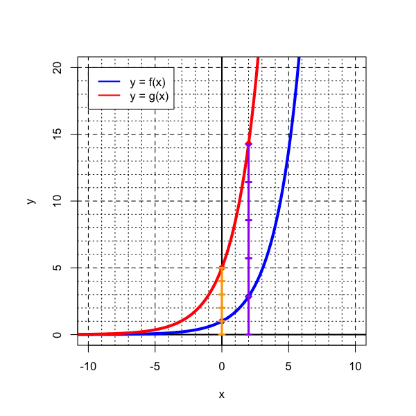

   $$\begin{align}
   f(x) &= 1.69^{x}\\\\
   g(x) &= 5\cdot 1.69^{x}
   \end{align}$$

   Instead of using the vertical stretch transformation, we could have used a horizontal shift. Notice the $g$ curve is congruent to the $f$ curve, just shifted to the left. Thus, we can express $g$ as a horizontally shifted version of $f$.

   $$g(x) = f(x+h)$$

   Or,

   $$g(x) = 1.69^{x+h}$$

   where $h$ represents the distance of the horizontal shift.
   - Find $h$. The tolerance is $\pm 0.01$.

#### Question

6. For [exponential functions](https://en.wikipedia.org/wiki/Exponential_function), a horizontal shift is equivalent to a vertical stretch. Consider the two functions below, where $g$ is equivalent to $f$ stretched vertically by a factor $6$:

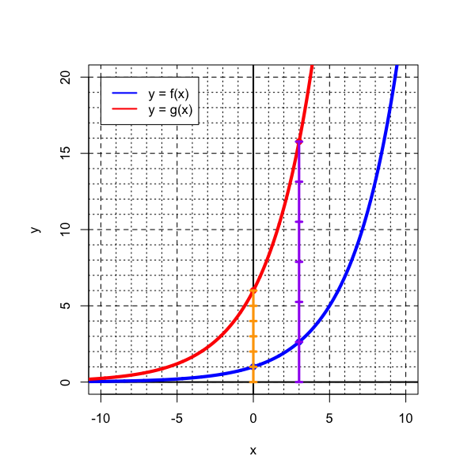

   $$\begin{align}
   f(x) &= 1.38^{x}\\\\
   g(x) &= 6\cdot 1.38^{x}
   \end{align}$$

   Instead of using the vertical stretch transformation, we could have used a horizontal shift. Notice the $g$ curve is congruent to the $f$ curve, just shifted to the left. Thus, we can express $g$ as a horizontally shifted version of $f$.

   $$g(x) = f(x+h)$$

   Or,

   $$g(x) = 1.38^{x+h}$$

   where $h$ represents the distance of the horizontal shift.
   - Find $h$. The tolerance is $\pm 0.01$.

#### Question

7. For [exponential functions](https://en.wikipedia.org/wiki/Exponential_function), a horizontal shift is equivalent to a vertical stretch. Consider the two functions below, where $g$ is equivalent to $f$ stretched vertically by a factor $6$:

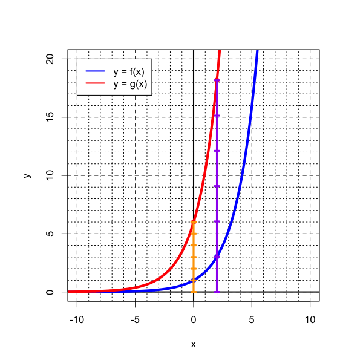

   $$\begin{align}
   f(x) &= 1.74^{x}\\\\
   g(x) &= 6\cdot 1.74^{x}
   \end{align}$$

   Instead of using the vertical stretch transformation, we could have used a horizontal shift. Notice the $g$ curve is congruent to the $f$ curve, just shifted to the left. Thus, we can express $g$ as a horizontally shifted version of $f$.

   $$g(x) = f(x+h)$$

   Or,

   $$g(x) = 1.74^{x+h}$$

   where $h$ represents the distance of the horizontal shift.
   - Find $h$. The tolerance is $\pm 0.01$.

#### Question

8. For [exponential functions](https://en.wikipedia.org/wiki/Exponential_function), a horizontal shift is equivalent to a vertical stretch. Consider the two functions below, where $g$ is equivalent to $f$ stretched vertically by a factor $5$:

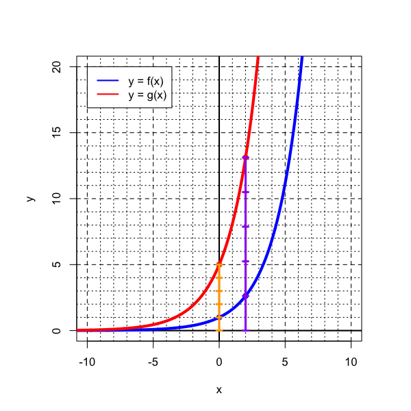

   $$\begin{align}
   f(x) &= 1.62^{x}\\\\
   g(x) &= 5\cdot 1.62^{x}
   \end{align}$$

   Instead of using the vertical stretch transformation, we could have used a horizontal shift. Notice the $g$ curve is congruent to the $f$ curve, just shifted to the left. Thus, we can express $g$ as a horizontally shifted version of $f$.

   $$g(x) = f(x+h)$$

   Or,

   $$g(x) = 1.62^{x+h}$$

   where $h$ represents the distance of the horizontal shift.
   - Find $h$. The tolerance is $\pm 0.01$.